# Introdução à Ciência de Dados

Mestrado Profissional em Administração

Prof. Washington Santos da Silva

IFMG - Campus Formiga

10 de julho de 2025

## Diário de Bordo

**O que vimos até aqui?**

- Aula 1 ✅
  - Apresentação da Disciplina ✅
  - Introdução e Contextualização ✅
  - O que é Ciência de Dados? ✅
  - Pesquisa Reproduzível e Ciência de Dados ✅
  - Papéis Profissionais ✅
  - Aplicações ✅
  - Habilidades Interpessoais e Analíticas ✅
  - Apresentação da Disciplina ✅
  - Configurações: Git/GitHub ✅
- Aula 2 ✅
  - Metodologia CRISP-DM ✅
  - Tipos de Análise de Dados ✅
  - Introdução ao RStudio e criação do **seu** Projeto da Disciplina ✅
  - Introdução ao Sistema de Publicação Quarto ✅
  - Introdução ao Git e GitHub: controle de versão e criação do **seu** repositório no GitHub ✅
- Aula 3 ✅
  - Breve Revisão sobre o RStudio ✅
  - Sistema de Publicação Quarto: (Cont.) ✅
  - Introdução ao Git e GitHub: (Cont.) ✅
  - Sessão Prática: Fluxo de trabalho integrando RStudio/Quarto/R/Git/GitHub ✅
- Aula 4 ✅
  - Conceitos de Variáveis e Observações em Estatística ✅
  - Conceito de Dados Organizados (*Tidy Data*) ✅
  - Tipos atômicos e classes principais de dados da linguagem R ✅
  - Tipos de Dados Tradicionais em Finanças: ✅
    - Dados em Secção-Cruzada (ou Transversal) (*Cross-Section Data*) ✅
    - Dados em Secções-Cruzadas Combinadas (*Pooled Cross-Section Data*) ✅
    - Dados em Séries Temporais (*Time Series Data*) ✅
    - Dados em Painel (ou Longitudinais) (*Panel Data*) ✅
  - Importação e Preparação de Dados Típicos de Finanças com exemplos práticos ✅
- Aula 5 ✅
  - Metodologia CRISP-DM: Fases 2 e 3 ✅
  - Revisão sobre Dados Organizados (*Tidy Data*) ✅
  - Introdução ao Pacote tidyr: função pivot_longer() ✅
  - Introdução ao Pacote dplyr: funções select() e filter() ✅
  - Exercícios ✅
- Aula 6 ✅
  - Função mutate ✅
  - Funções group_by e summarize ✅
  - Exercícios ✅
- Aula 7 ✅
  - Introdução ao Pacote dplyr: Tipos Básicos de *joins* ✅
  - Exercícios ✅
- Aula 8 ✅
  - Avaliação 1
- Aula 9 ✅
  - Modelos ✅
  - Conceitos Fundamentais de Probabilidade ✅
    - O que é Probabilidade? ✅
    - Probabilidade Condicional e Independência ✅
    - Amostra Aleatória ✅
    - Variáveis Aleatórias e Funções de Probabilidade ✅
    - Função de Distribuição Acumulada ✅
    - Lei dos Grandes Números ✅
  - Distribuições de Probabilidade de VA Discretas ✅
    - Distribuição de Bernoulli ✅
    - Características de uma Distribuição de Probabilidade ✅
      - Valor Esperado ✅
      - Variância e Desvio-Padrão ✅
      - Assimetria e Curtose ✅
  - Distribuição Binomial ✅
- Aula 10 ✅
  - Distribuições de Probabilidade de VA Contínuas ✅
    - Distribuição Uniforme ✅
    - Método da Transformação Invesa da FDA ✅
    - Distribuição Normal ✅
    - Teorema Central do Limite ✅
    - Fundamentos de Simulação de Monte Carlo ✅
    - Distribuição Conjunta de Variáveis Aleatórias ✅
    - Distribuição Condicional ✅
    - Distribuição Marginal ✅
    - Independência de Variáveis Aleatórias ✅
    - Covariância e Correlação ✅
- Aula 11 ✅
  - Simulação de Monte Carlo - Aplicações ✅
  - Aplicação - Valor-em-Risco (VaR) ✅
    - Pacote tidyquant, Séries de Preços e de Rretornos de Acões ✅
    - Método Paramétrico ✅
    - Método Histórico ✅
    - Método de Simulação de Monte Carlo ✅
  - Aplicação - ES/CVaR ✅
- Aula 12 ✅
  - Revisão de Matemática Básica ✅
  - Estatística, Probabilidade e Simulação ✅
  - Parâmetro, Estimador/Estatística, Estimativa ✅
  - Métodos de Inferência Estatística ✅
  - Estimação Pontual de Parâmetros Populacionais ✅
    - Método da Máxima Verossimilhança ✅
    - Propriedades de Estimadores ✅

## Nesta Aula

**Tópicos - Fundamentos de Estatística e Simulação**

- Método da Máxima Verossimilhança
  - Informação de Fisher
- Distribuição Amostral
- Estimação por Intervalo de Confiança

**Diretrizes para Aulas Mais Produtivas**

⌨️ **Código com método:**

95% dos erros são evitáveis com:

- Atenção na digitação
- Respeitar a sequência lógica de etapas
- Revisão antes de pedir ajuda

🤝 **Inteligência colaborativa:**

- Compartilhe conhecimento
- Resolva questões técnicas simples com colegas próximos
- Reserve ao professor as dúvidas conceituais complexas

💪 **Capacidade de Resolver Problemas**

Cada erro resolvido é uma evolução da sua habilidade analítica

## O que é compreender algo?

“Knowing the name of something is not the same as knowing something.” — Richard Feynman

## Métodos de Inferência Estatística

**Descrição**

Inferência estatística são métodos que consistem em usar dados de uma amostra para tirar conclusões sobre parâmetros de uma população subjacente da qual a amostra foi retirada.

**Escola Frequentista/Máxima Verossimilhança**

- Estimação de Parâmetros:
  - Pontual ✓
  - Estimação por Intervalo de Confiança
- Testes de Significância

# Estimação por Máxima Verossimilhança

## Estimador de Máxima Verossimilhança

**Propriedades dos Estimadores de MV**

Agora, sabemos que os estimadores de máxima verossimilhança possuem boas propriedades:

- Os estimadores de MV são **assintoticamente não viesados**, à medida que que $n$ aumenta, qualque viés do estimador tende a zero.
- Os estimadores de MV são **consistentes**: à medida que $n$ aumenta, o estimador de MV converge para o valor verdadeira do parâmetro da população.
- Os estimadores de MV são **assintoticamente eficientes**: para $n$ grande, eles possuem menor variância do que outros estimadores.
- A distribuição amostral dos estimadores de MV é **assintóticamente normal**.

## Estimadores de Máxima Verossimilhança

**Resumo**

- Seja $Y$ uma variável aleatória (discreta ou contínua) que representa um fenômeno aleatório de interesse e que é modelada por uma distribuiçào de probabilidades.
- Seja $Y = (y_1, y_2,\ldots, y_n)$ uma amostra observada da VA Y, ou seja, os dados.
- A distribuição de probabilidades de $Y$ é descrita por um vetor de parâmetros $\theta$ desconhecido os quais, portanto, precisam ser estimados usando os dados observados.
- Seja $f(y|\theta)$ a função de verossimilhança, que é proporcional à probabilidade condicional dos dados, condicional ao vetor de parâmetros $\theta$.
- Os estimadores de MV de $\theta$ são aqueles que **maximizam a funçào de verossimilhança**. Ou seja, são os estimadores que maximizam a probabilidade de ocorrência dos dados observados.
- Para encontrar os estimadores de MV de $\theta$, maximizamos a **função de log-verossimilhança**, por ser computacionalmente mais simples.

## Distribuições de Bernoulli e Binomial

**Distribuições de Bernoulli e Binomial**

#### **Distribuição de Bernoulli**

Seja $Y_i\in\{0,1\}$ com probabilidade de sucesso $p$ e de fracasso $1-p$.

$$P(Y_i = y_i) = p^y(1 - p)^{1 - y}$$

#### **Distribuição Binomial** – $n$ ensaios i.i.d. Bernoulli

$$Y=\sum_{i=1}^n Y_i\sim\operatorname{Bin}(n,p),\;\;\;P(Y=y)=\binom{n}{y}p^{y}(1-p)^{\,n-y}$$

$$E(Y)=np,\qquad V[Y] = np(1-p)$$

#### **Aplicações**

- Econometria: Modelos logit e probit
- Finanças: Modelos Risco de crédito (*default*)
- Finanças: Precificação de Opções

## Aplicação

**EMV de $p$**

- Nos EUA, uma pesquisa denominada *General Social Survey (GSS)* de 2018 perguntou aos participantes: “*Você acredita que existe vida após a morte?*”
- Entre os 2.123 indivíduos da amostra aleatória, 1.720 declararam que acreditam que há vida após a morte.
- Vamos obter o EMV de $p$, a proporção de pessoas que acreditam que há vida após a morte.

## EMV da Probabilidade de Sucesso $p$

**Derivação do EMV de $p$**

Suponha $k$ amostras independentes $x_1,\ldots,x_k$ de $\operatorname{Bin}(n,p)$.

#### Função de verossimilhança

Ignorando o termo constante $\binom{n}{x_i}$:

$$\begin{aligned}
L(p) &= \prod_{i=1}^{k}\binom{n}{x_i}p^{x_i}(1-p)^{n-x_i}, \\
L(p) &\propto \prod_{i=1}^{k} p^{x_i} (1 - p)^{n - x_i}
\end{aligned}$$
Portanto, a função de log‑verossimilhança é:

$$\log L(p) = \sum_{i=1}^k\bigl[x_i\,\log p+(n-x_i)\,\log(1-p)\bigr]$$

#### Condição de 1ª ordem (score)

$$\frac{\partial \log L(p)}{\partial p}=\frac{\sum x_i}{p}-\frac{kn-\sum x_i}{1-p} = 0$$

Multiplicando por $p(1-p)$ e isolando $p$:

$$\hat p = \frac{\sum x_i}{kn}=\bar x$$

#### Condição de 2ª ordem

$$\frac{\partial^{2} \log L(p)}{\partial p^{2}}=-\frac{\sum x_i}{p^{2}}-\frac{kn-\sum x_i}{(1-p)^{2}}<0$$

Logo $\hat p$ maximiza $L(p)$.

## EMV de $p$

**Usando a Linguagem R**

- Vamos obter o EMV de $p$, a proporção de pessoas que acreditam que há vida após a morte usando R.
- Além disso, vamos visualizar a função de verossimilhança e a função de log-verossimilhança

## O Exemplo anterior em R

```r
# Função para plotar a função de verossimilhança e a função de log-verossimilhança
plot_funcao_mv = function(y,n)
{
    L <-  function(p) dbinom(y,n,p)
    emv <- optimize(L, interval = c(0,1), maximum = TRUE)$max
    p <-  (1:100)/100

    # graficos da funcao de MV e de Log-MV
    par(mfrow = c(1,1))
    plot(p, L(p), type = 'l')
    abline(v = emv)
    plot(p, log(L(p)), type = 'l')
    abline(v = emv)
    round(emv, 2)
}
plot_funcao_mv(1720,2123)
```

## O Exemplo anterior em R

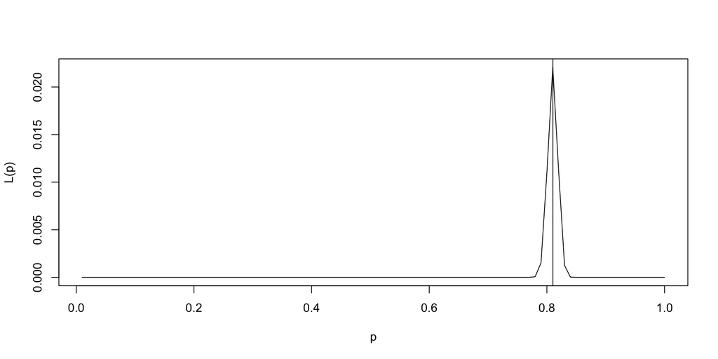

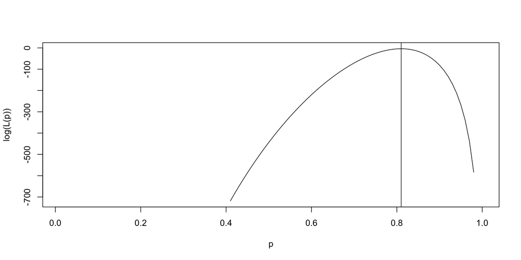

```
[1] 0.81
```

## Curvatura da Função de Log‑Verossimilhança

**Resumo**

- A **curvatura da função de log-verossimilhança** contém **todas as informações** que os **dados** fornecem sobre um vetor de **parâmetros** $\theta$, dado o modelo.
- Vamos entender o porquê disso. A maior parte da Estatísica moderna pode ser aprendida com um bom domínio destes conceitos críticos.
- Vejamos alguns formatos possíveis da curvatura da função de log-verossimilhança ($\ln f(X|\theta)$) em relação à $\theta$.

## Informação de Fisher $I(p)$

**Curvatura da Função de Log‑Verossimilhança**

A **Informação de Fisher** é uma maneira de medir a quantidade de informação que uma amostra de uma VA $Y$ contém sobre um parâmetro desconhecido $\theta$ da distribuição de probabilidade de $Y$. **Por quê?**

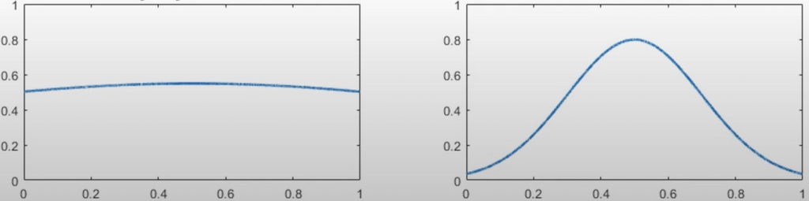

Figura 1: Curvatura da Função de Log-Verossimilhança

- Se a curvatura de $\log L(\theta)$ em relação às variações de $\theta$ é **pequena**, há muitos valores de $\theta$ que produzem valores de $\log L(\theta)$ próximos.
  - Neste caso, a informação sobre o valor de $\theta$ é **vaga ou pequena**.
- Se a curvatura de $\log L(\theta)$ é **grande** em relação às variações em $\theta$, é mais provável encontrar o valor “correto” de $\theta$ usando os dados, pois há mais probabilidade concentrada em torno de $\theta$.
  - Neste caso, a informação sobre o valor de $\theta$ é **grande**.
- Isso sugere estudar algum tipo de **variância** em relação ao vetor de parâmetros $\theta$. Essa é a motivação para a Informacão de Fisher.

## Informação de Fisher $I(p)$

**Informação de Fisher**

- A resposta refere-se ao conceito de **Informação de Fisher**.
- Em Estatística, a **Informação de Fisher** é uma maneira de medir a quantidade de informação que uma amostra de uma variável aleatória $Y$ contém sobre um parâmetro desconhecido $\theta$ de uma distribuição de probabilidade que modela $Y$.

Se o score é dado $S(p) = \dfrac{\partial \log L(p)}{\partial p}$, a informação de Fisher é definida como **variância** do score:

$$I(p) = -E\bigl[S(p)^{2}\bigr] = -E\Bigl[\frac{\partial^{2} \log L(p)}{\partial p^{2}}\Bigr]=\frac{kn}{p(1-p)}$$

- Quanto mais amostras, mais informação acumulada — o numerador é $kn$

#### Por que tomar o valor esperado?

- Como a função de log-verossimilhança depende dos **dados específicos observados**, a segunda derivada de $\log L(\theta)$ também depende da amostra.
- Mas a Informação de Fisher quer medir quanta informação uma **distribuição** (não uma amostra específica) fornece sobre $\theta$.

Então usamos:

- O **Valor Esperado** da derivada segunda, tomada sobre a distribuição dos dados, assumindo que $\theta$ é o valor verdadeiro.
- Isso nos dá uma **medida média** da curvatura, que independe de uma amostra específica.

## Informação de Fisher

**Aplicações Atuais**

#### 1. Robótica: Localização e Mapeamento (SLAM)

- Em sistemas de **robótica móvel**, a Informação de Fisher quantifica **quanto um sensor contribui para estimar a posição do robô**.
- É usada para **planejar trajetórias que maximizem a informação esperada**, otimizando o processo de **localização e mapeamento simultâneos (SLAM)** (Carrillo, Reid e Castellanos, 2012).

#### 2. Aprendizado de Máquina: Otimização com *Natural Gradient Descent*

- O objetivo é **acelerar e estabilizar o treinamento de modelos complexos**, como redes neurais profundas.
- A matriz da Informação de Fisher define uma **métrica no espaço dos parâmetros**, refletindo a geometria da função de perda.
- O método do **gradiente natural** utiliza essa métrica para atualizar os parâmetros em direções mais informativas, levando em conta a curvatura local.
- Isso resulta em **convergência mais rápida**, evitando instabilidades comuns em otimização com gradiente padrão (Amari, 1998; Martens, 2020).

# Distribuição Amostral

## O que é uma Distribuição Amostral?

**Distribuição Amostral**

- Um **estimador** (ou **estatística**) $T(Y)$ é uma função dos dados da amostra.
- Antes da coleta dos dados, $T$ é uma **variável aleatória** — seus valores possíveis seguem uma **distribuição de probabilidade**.
- Essa distribuição é chamada de **distribuição amostral do estimador**.
- A distribuição amostral descreve:
  - A **variabilidade** do estimador entre diferentes amostras.
  - O **valor esperado** e a **precisão** do estimador em relação ao parâmetro populacional.

> A **inferência estatística** baseia-se nessa distribuição para estimar parâmetros e quantificar incertezas.

## Distribuição de $\hat{p}$ (Proporção Amostral)

**Dois Casos**

#### Amostra pequena ($n$ pequeno)

$$\hat{p} = \frac{Y}{n}, \quad \text{com } Y \sim \operatorname{Bin}(n, p)$$

- $Y$ representa o **número de sucessos** em $n$ tentativas independentes, com probabilidade $p$ de sucesso (modelo Bernoulli).
- Assim, $Y$ segue uma **distribuição binomial**, e $\hat{p}$, sendo $Y/n$, tem uma distribuição **escalada da binomial**.
- A distribuição de $\hat{p}$ é **discreta**, e sua forma depende de $n$ e $p$.
- Propriedades:

  $E(\hat{p}) = p$,  
  $V(\hat{p}) = \dfrac{p(1 - p)}{n}$

#### Amostra grande ($n \to \infty$)

- Pelo **Teorema Central do Limite**, a distribuição de $\hat{p}$ aproxima-se de uma normal:

$$\hat{p} \;\dot{\sim}\; N\!\left(p,\;\dfrac{p(1 - p)}{n}\right)$$

> Aproximação válida se $np > 10$ e $n(1 - p) > 10$.

## Distribuição da Média Amostral $\bar{X}$

**Definição e Propriedades**

A **média amostral** $\bar{X}$ é definida como:

$$\bar{X} = \frac{1}{n} \sum_{i=1}^n X_i$$

onde $X_1, \dots, X_n$ são observações independentes e identicamente distribuídas (i.i.d.), com média $\mu$ e variância $\sigma^2$.

#### Propriedades:

- **Valor esperado:**

  $$E(\bar{X}) = \mu$$
  - $\bar{X}$ é um **estimador não-viesado** de $\mu$.
- **Variância:**

  $$V(\bar{X}) = \frac{\sigma^2}{n}$$
  - A variabilidade da média diminui com o tamanho da amostra.
- **Erro-padrão:**

  $$\operatorname{EP}(\bar{X}) = \frac{\sigma}{\sqrt{n}}$$
  - Mede a incerteza da estimativa de $\mu$ com base em uma amostra de tamanho $n$.

## Teorema Central do Limite (TCL) e a Média Amostral

**O que diz o TCL?**

Seja $X_1, \dots, X_n$ uma amostra aleatória de uma população com média $\mu$ e desvio padrão $\sigma$.

Mesmo que a distribuição da população **não seja normal**, a **distribuição da média amostral** $\bar{X}$ se aproxima de uma normal quando $n$ é grande.

#### Resultado:

$$\frac{\sqrt{n}(\bar{X} - \mu)}{\sigma}\;\xrightarrow{d}\; N(0, 1)$$

Ou equivalentemente:

$$\bar{X} \;\dot{\sim}\; N\left(\mu, \frac{\sigma^2}{n} \right)$$

#### Condições para aplicar o TCL:

- Amostra aleatória e observações independentes.
- Tamanho amostral suficientemente grande.

> Regra prática: $n \gtrsim 30$ geralmente é suficiente, especialmente se a população não for muito assimétrica ou com outliers.

## Teorema Central do Limite

Independente da forma da distribuição da população, na medida que $n$ aumenta, a Distribuição Amostral de $\bar{X}$ torna-se mais estreita e converge para uma distribuição normal.

## Variabilidade da Distribuição Amostral

**Erro‑Padrão (EP)**

- O **erro-padrão** é o desvio padrão da distribuição amostral de um estimador.
  - Mede a **variabilidade do estimador** devida à **aleatoriedade da amostragem**.
- Um erro-padrão menor indica um estimador **mais preciso**.
- Fatores que afetam o erro-padrão:
  - **Variabilidade dos dados na população**: quanto maior $\sigma^2$ ou $p(1 - p)$, maior o erro-padrão.
  - **Tamanho da amostra** ($n$): quanto maior $n$, menor o erro-padrão.

> Obs.: “População” refere-se ao conjunto total de onde as amostras são extraídas.

## Método Delta

**Visão Geral**

O **Teorema Central do Limite** mostra que muitas estatísticas amostrais têm distribuição aproximadamente normal quando a amostra é grande.

O **Método Delta** estende esse resultado para **funções não lineares** dessas estatísticas.

#### Versão Simplificada:

Seja $T$ um estimador de um parâmetro $\theta$, tal que:

$$\sqrt{n}(T - \theta) \overset{d}{\longrightarrow} N(0, \tau^2)$$

e seja $g(\cdot)$ uma função diferenciável em $\theta$, então:

$$\sqrt{n}\left[g(T) - g(\theta)\right] \overset{d}{\longrightarrow}
N\left(0,\, [g'(\theta)]^2 \cdot \tau^2 \right)$$

#### Interpretação:

- Se $T$ é assintoticamente normal, então **qualquer função suave de $T$** também será assintoticamente normal.
- A variância de $g(T)$ depende da inclinação (derivada) de $g$ no ponto $\theta$.
- Permite aproximar distribuições amostrais de transformações como $\log(T)$, $\exp(T)$, $1/T$, etc.

#### Aplicações:

- Construção de intervalos de confiança para transformações de estimadores.
- Justificativa teórica para testes e estimadores não-lineares.

# Estimação por Intervalo de Confiança

## Por que Intervalos de Confiança?

**O Desafio do Analista de Dados**

**Problema**: Uma estimativa pontual informa um valor, mas **não** quantifica a incerteza associada à inferência de uma amostra para a população.

**Exemplo**: Satisfação média de 7.2 pontos em amostra de 100 clientes.

**Pergunta**: Qual a **precisão** desta estimativa?

**Solução**: Intervalos de confiança não reduzem a incerteza, mas **quantificam a incerteza da amostragem**, fornecendo um intervalo onde o parâmetro populacional provavelmente se encontra.

**Comunicação Correta**:

> “A satisfação média de todos os clientes está entre 6.8 e 7.6 pontos, com 95% de confiança.”

Quantifica a incerteza da amostragem.

## Importância da Amostragem Aleatória

**Por que a aleatoriedade é importante?**

Os intervalos de confiança assumem que os dados provêm de uma **amostra aleatória** da população de interesse. Esta condição é fundamental para a validade dos resultados.

**Consequências da aleatoriedade**:

- Garante que cada elemento da população tenha chance conhecida de seleção
- Permite que as propriedades probabilísticas dos estimadores sejam válidas
- Assegura que os intervalos tenham as propriedades de cobertura desejadas

**Responsabilidade do analista**: Sempre verificar e documentar o método de amostragem utilizado, alertando sobre limitações quando a aleatoriedade não for garantida.

## Estimação por Intervalo de Confiança

**Definição Formal**

Sejam $T_L(Y)$ e $T_U(Y)$ duas funções dos dados amostrais $Y = (y_1, \dots, y_n)$ tais que:

$$P\left[ T_L(Y) \leq \theta \leq T_U(Y) \right] = 1 - \alpha, \quad \text{para todo } \theta$$

Após a observação dos dados, o intervalo $[T_L(Y), T_U(Y)]$ é chamado de **intervalo de confiança** de nível $1 - \alpha$.

#### Confiança vs. Probabilidade

- A probabilidade $1 - \alpha$ se refere ao processo aleatório de geração dos dados, não ao parâmetro $\theta$.
- Após observar os dados, o intervalo contém ou não $\theta$. Mas, antes da observação, o intervalo é aleatório.
- A interpretação é frequentista: $\theta$ é fixo; o intervalo é variável.

## Intervalos de Confiança

**Interpretação Formal**

- Um intervalo com 95% de confiança, por exemplo, implica que, se fossem retiradas 100 amostras e fossem obtidas 100 estimativas por IC, espera-se que 95% dos intervalos calculados contenham o valor verdadeiro do parâmetro.
- A Figura 2 ilustra, mostrando 100 estimativas de IC $[TL(y), TU(y)]$ para um parâmetro $\theta$, com base em 100 amostras extraídas alguma população. Os 5 intervalos em vermelho não incluem $\theta$.

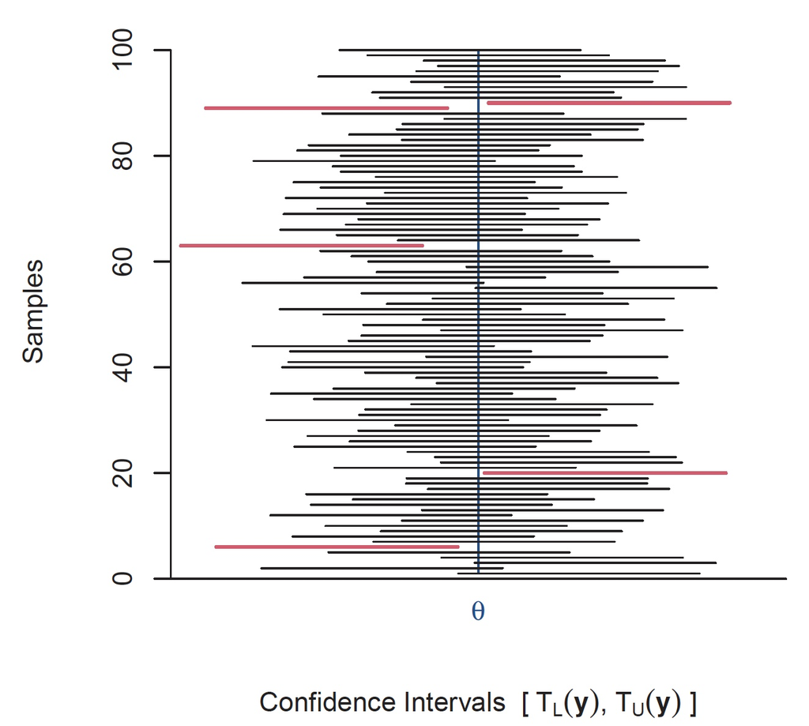

Figura 2: Intervalos de confiança de 95% para um parâmetro $\theta$ com base em 100 amostras separadas de uma população. Os intervalos de confiança em vermelho são aqueles que não incluem $\theta$.

## Estimador por IC para $p$

**Construção de um Estimador por IC para $p$**

Segundo Fisher, sob algumas condições, a distribuição assintótica do **estimador de máxima verossimilhança (EMV)** é:

$$\hat{\theta} \overset{d}{\longrightarrow} \mathcal{N}\left(\theta, \frac{1}{I(\theta)}\right)$$

Isso implica que a **variância assintótica** do EMV é inversamente proporcional à **informação de Fisher**:

$$\operatorname{Var}(\hat{\theta}) \approx \frac{1}{I(\theta)}$$

Assim, a função de log-verossimilhança não serve apenas para encontrar $\hat{\theta}$, mas também para avaliar sua **precisão**.

- Um estimador cuja variância assintótica atinge $\frac{1}{I(\theta)}$ é dito **assintoticamente eficiente**.

Na prática, como $\theta$ é desconhecido, estimamos a variância substituindo $\theta$ pelo EMV $\hat{\theta}$:

$$\widehat{\operatorname{Var}}(\hat{\theta}) \approx \frac{1}{I(\hat{\theta})}$$

#### Aplicação: Estimador de $p$ na Binomial

Para $X_1, \dots, X_k \overset{\text{iid}}{\sim} \operatorname{Bin}(n, p)$, a informação de Fisher é:

$$I(p) = \frac{kn}{p(1 - p)}$$

Portanto, a variância assintótica do EMV $\hat{p}$ é:

$$\operatorname{Var}(\hat{p}) \approx \frac{1}{I(p)} = \frac{p(1 - p)}{kn}$$

Pela normalidade assintótica, temos:

$$\hat{p} \overset{d}{\longrightarrow} \mathcal{N}\left(p, \frac{p(1 - p)}{kn}\right)$$

Ou seja:

- $E(\hat{p}) = p$
- $\operatorname{Var}(\hat{p}) = \dfrac{p(1 - p)}{kn}$
- $\sigma_{\hat{p}} = \sqrt{\dfrac{p(1 - p)}{kn}}$

## Estimador por IC para $p$

**Método da Quantidade Pivotal**

Uma **quantidade pivotal** é uma função dos dados e do parâmetro:

$$Q(X_1, \dots, X_n; \theta)$$

com distribuição conhecida e **independente** de $\theta$.

Se $T(Y) \sim N(\theta, \sigma^2)$, então:

$$Z = \frac{T(Y) - \theta}{\sigma} \sim N(0, 1)$$

#### Construindo o Intervalo com a Quantidade Pivotal

Sabemos que:

$$P[-1.96 \leq Z \leq 1.96] = 0.95$$

Se:

$$Z = \frac{T(Y) - \theta}{\sigma}$$

então:

$$P\left[T(Y) - 1.96\sigma \leq \theta \leq T(Y) + 1.96\sigma \right] = 0.95$$

## Estimador por IC para $p$

**Ligação com EMV, Teorema Central do Limite e Fisher**

- Pelo **Teorema Central do Limite**, $\bar{X} \to \mathcal{N}(\mu, \sigma^2/n)$ para $n$ grande.

Estimadores de máxima verossimilhança (EMV) são **assintoticamente normais**:

$$\hat{\theta} \overset{d}{\rightarrow} \mathcal{N}\left(\theta, \frac{1}{I(\theta)}\right)$$

Isso nos permite aplicar o **método da quantidade pivotal** com:

$$Z = \frac{\hat{\theta} - \theta}{\sigma_{\hat{\theta}}}$$

Intervalos assintóticos:

$$\hat{\theta} \pm z_{\alpha/2} \cdot \sigma_{\hat{\theta}}$$

## Intervalo de Confiança Assintótico para $p$

**Derivação - Intuição**

Sabemos que:

$$\hat{p} \overset{d}{\rightarrow} N\left(p, \frac{p(1 - p)}{n}\right)$$

Logo:

$$Z = \frac{\hat{p} - p}{\sqrt{\frac{p(1 - p)}{n}}} \to N(0,1)$$

Aproximamos com $\hat{p}$ no denominador:

$$\boxed{
\hat{p} \pm z_{\alpha/2} \cdot \sqrt{\frac{\hat{p}(1 - \hat{p})}{n}}
}$$

- 95%: $z = 1.96$
- 99%: $z = 2.58$

Exemplos:

- 95%: como $\alpha = 0.05 \Rightarrow \alpha/2 = 0.025 \Rightarrow z_{0.025} = 1.96$, (em R: `qnorm(1 - 0.025) = qnorm(0.975)`), então:

  $\hat{p} \pm 1.96 \sqrt{\dfrac{\hat{p}(1 - \hat{p})}{n}}$
- 99%: como $\alpha = 0.01 \Rightarrow \alpha/2 = 0.005 \Rightarrow z_{0.005} = 2.58$, (em R: `qnorm(1 - 0.005) = qnorm(0.995)`), então:

  $\hat{p} \pm 2.58 \sqrt{\dfrac{\hat{p}(1 - \hat{p})}{n}}$

#### Considerações Práticas

- A normal aproxima bem a binomial se:

$$np \geq 10 \quad \text{e} \quad n(1 - p) \geq 10$$

- Caso essas condições não sejam atendidas, intervalos baseados nela podem ter nível de confiança real inferior ao desejado.
- Alternativas incluem métodos exatos (Clopper-Pearson) ou correções (Wilson, Agresti-Coull).

## Resumo

**Resumo**

1. Encontramos o **estimador** $\hat{p}$ pelo **método da máxima verossimilhança**.
2. Derivamos sua **variância assintótica** com a **informação de Fisher**.
3. Aplicamos o **TCL** para obter a **distribuição amostral** de $\hat{p}$.
4. Usamos o **método da quantidade pivotal** para construir um intervalo de confiança.

#### Intervalos de Confiança para $p$:

- **Para amostras grandes (método de Wald):**

$$\boxed{
\hat{p} \pm z_{\alpha/2} \cdot \sqrt{\frac{\hat{p}(1 - \hat{p})}{n}}
}$$

Para **$n$ pequeno** ou $\hat{p}$ próximo de 0 ou 1, pode ser imprecisa.

- **Para amostras pequenas (intervalo exato de Clopper–Pearson):**

Usado, por exemplo, na função `binom.test()` do R. Baseia-se na distribuição binomial e fornece cobertura exata.

## IC para uma ou duas proporções

**Resumo**

|  | **Uma Proporção** | **Duas Proporções** |
| --- | --- | --- |
| **Suposições** | Amostra aleatória, variável binária | Amostras aleatórias independentes, variáveis binárias |
| **Parâmetro** | $p$ | $p_1 - p_2$ |
| **Estimador** | $\hat{p} = \dfrac{Y}{n}$ | $\hat{p}_1 = \dfrac{Y_1}{n_1},\; \hat{p}_2 = \dfrac{Y_2}{n_2}$ |
| **Quantidade pivotal** | $z = \dfrac{\hat{p} - p}{EP}$ | $z = \dfrac{(\hat{p}_1 - \hat{p}_2) - (p_1 - p_2)}{EP}$ |
| **Erro-padrão (Wald)** | $\sqrt{\dfrac{\hat{p}(1 - \hat{p})}{n}}$ | $\sqrt{\dfrac{\hat{p}_1(1 - \hat{p}_1)}{n_1} + \dfrac{\hat{p}_2(1 - \hat{p}_2)}{n_2}}$ |
| **IC (Wald)** | $\hat{p} \pm z_{\alpha/2} \cdot EP$ | $(\hat{p}_1 - \hat{p}_2) \pm z_{\alpha/2} \cdot EP$ |

## Funções R para IC para Proporções

**prop.test() e binom.test()**

**`prop.test()`**

- Usa a distribuição **qui-quadrado** com **correção de continuidade de Yates**
- Intervalo é geralmente **mais conservador** do que o método de Wald
- Adequado para amostras grandes ($n \geq 30$)
- Sintaxe: `prop.test(x, n, conf.level = 0.95)`
- Para duas proporções: `prop.test(c(x1, x2), c(n1, n2))`

**`binom.test()`**:

- Intervalo **exato** com base na distribuição binomial
- Adequado para amostras pequenas ou quando se deseja **precisão máxima**
- Sintaxe: `binom.test(x, n, conf.level = 0.95)`
- Apenas para uma proporção

**Argumentos**:

- `x`: número de sucessos observados
- `n`: tamanho da amostra
- `conf.level`: nível de confiança (padrão: 0.95)

**Recomendações**:

- Para $n \geq 30$ e proporções longe de 0 ou 1, `prop.test()` é uma escolha prática e confiável
- Para amostras pequenas ou proporções extremas, prefira `binom.test()` para maior precisão

## Intervalos de Confiança para uma ou duas médias

**Resumo**

|  | **Uma Média** | **Duas Médias** |
| --- | --- | --- |
| **Suposições** | Amostra aleatória, população normal | Amostras aleatórias, populações normais |
|  |  | (variâncias iguais ou não) |
| **Parâmetro** | $\mu$ | $\mu_1 - \mu_2$ |
| **Estimador** | $\bar{Y}$ | $\bar{Y}_1 - \bar{Y}_2$ |
| **Quantidade pivotal** | $t = \dfrac{\bar{Y} - \mu}{EP}$ | $t = \dfrac{(\bar{Y}_1 - \bar{Y}_2) - (\mu_1 - \mu_2)}{EP}$ |
| **Erro-padrão (EP)** | $\dfrac{s}{\sqrt{n}}$ | Com variâncias **iguais**: |
|  |  | $\quad s_p \cdot \sqrt{\dfrac{1}{n_1} + \dfrac{1}{n_2}}$ |
|  |  | $\quad s_p^2 = \dfrac{(n_1 - 1)s_1^2 + (n_2 - 1)s_2^2}{n_1 + n_2 - 2}$ |
|  |  | Com variâncias **desiguais** (Welch): |
|  |  | $\quad \sqrt{\dfrac{s_1^2}{n_1} + \dfrac{s_2^2}{n_2}}$ |
| **IC (geral)** | $\bar{Y} \pm t_{\alpha/2}(EP)$ | $(\bar{Y}_1 - \bar{Y}_2) \pm t_{\alpha/2}(EP)$ |
| **Distribuição t** | gl = $n - 1$ | gl = $n_1 + n_2 - 2$ (iguais) ou Welch (desiguais) |

## Função R para Intervalos de Confiança de Médias

**Função t.test()**

**t.test()**: Implementa intervalos de confiança e testes de significância para médias.

**Para uma média**:

```r
t.test(dados, conf.level = 0.95)
```

**Para duas médias (amostras independentes)**:

```r
t.test(grupo1, grupo2, conf.level = 0.95)
```

**Para duas amostras pareadas**:

```r
t.test(antes, depois, paired = TRUE, conf.level = 0.95)
```

**Argumentos**:

- `conf.level`: nível de confiança (padrão 0.95)
- `var.equal`: assumir variâncias iguais (padrão FALSE, usa correção de Welch)
- `paired`: para amostras pareadas

**Extração de resultados**: Use `resultado$conf.int` para obter apenas o intervalo.

## Aplicação 1

**Estimação de Intervalo de Confiança para uma Proporção**

- Uma pesquisa do Eurobarômetro de 2019 relatou que a porcentagem de pessoas que são ateístas ou agnósticas varia na Europa Ocidental entre 9% na Irlanda e 52% na Holanda.
- Intervalos de confiança mostram a precisão dessas estimativas.
- Vamos obter uma estimativa por intervalo de confiança da proporção de holandeses que são ateístas ou agnósticos para o caso da Holanda, onde dos 1.497 entrevistados, 778 relataram ser ateus ou agnósticos.

```r
# número total de entrevistados na Holanda
n <- 1497

# número de entrevistados que relataram ser ateus ou agnósticos
x <- 778

# Intervalo para p
ic_holanda <- binom.test(x, n, conf.level = 0.95)
ic_holanda
```

```
    Exact binomial test

data:  x and n
number of successes = 778, number of trials = 1497, p-value = 0.13
alternative hypothesis: true probability of success is not equal to 0.5
95 percent confidence interval:
 0.49405 0.54529
sample estimates:
probability of success
               0.51971
```

```r
# Obtendo somente a estimativa por intervalo de confiança
round(ic_holanda$conf.int, 2)
```

```
[1] 0.49 0.55
attr(,"conf.level")
[1] 0.95
```

## Aplicação 2

**Estimação de Intervalo de Confiança para Comparar Duas Proporções**

- A pesquisa realizada por Benson *et al.* (2006) utilizou pacientes de seis hospitais dos EUA que iriam receber cirurgia de revascularização do miocárdio. Os pacientes foram aleatoriamente designados para dois grupos.
- Para um grupo, os cristãos, os voluntários foram instruídos a orar por uma cirurgia bem-sucedida com uma recuperação rápida e saudável e sem complicações.
- A oração começou na noite anterior à cirurgia e continuou por duas semanas. O outro grupo não teve voluntários orando por eles.
- A resposta foi se complicações médicas ocorreram dentro de 30 dias da cirurgia.
- A tabela a seguir sumariza os resultados:

```
        Complications
        -------------
Prayer   Yes   No       Total
Yes      315   289      604
No       304   293      597
```

- Seja $p_1$ a proporção de complicações para os pacientes que tinham um grupo de oração.
- Seja $p_2$ a proporção de complicações para os pacientes que não tinham um grupo de oração.
- Essas são proporções populacionais para a população conceitual que esse exemplo representa.
- Da tabela anterior, as proporções amostrais ($\hat p_1$, $\hat p_2$) que tiveram complicações são:

$$\hat{p}_1 = \frac{315}{604} = 0,522, \,\, \hat{p}_2 = \frac{304}{597} = 0,509$$

Agora podemos usar a linguagem R para obter um IC para a diferença entre $p_1 - p_2$:

```r
# número total de pacientes no grupo de oração
n1 <- 604

# número de pacientes que tiveram complicações no grupo de oração
x1 <- 315

# número total de pacientes no grupo sem oração
n2 <- 597

# número de pacientes que tiveram complicações no grupo sem oração
x2 <- 304

# Intervalo para p1 - p2
ic_oracao <- prop.test(x = c(x1, x2), n = c(n1, n2), conf.level = 0.95)
ic_oracao
```

```
    2-sample test for equality of proportions with continuity correction

data:  c(x1, x2) out of c(n1, n2)
X-squared = 0.136, df = 1, p-value = 0.71
alternative hypothesis: two.sided
95 percent confidence interval:
 -0.045881  0.070502
sample estimates:
 prop 1  prop 2
0.52152 0.50921
```

```r
# Obtendo somente a estimativa por intervalo de confiança
round(ic_oracao$conf.int, 2)
```

```
[1] -0.05  0.07
attr(,"conf.level")
[1] 0.95
```

#### Reportando o resultado

- A diferença na proporção de pacientes que tiveram complicaçõs entre o grupo de pacientes que contaram com um grupo de oração (52%) e o grupo controle (51%) foi de 0,01 (IC 95% [-0.05, 0.07]), indicando que, com 95% de confiança, a verdadeira diferença na proporção de complicações entre os grupos está entre -0.05 e 0,07.
- Visto que o intervalo de confiança **contém zero**, os dados da pesquisa fornecem evidência de que não há diferença estatisticamente significativa na proporção de complicações entre os grupos.

## Aplicação: Testes A/B

**Experimento Controlado**

- **Definição:**

Um teste A/B é um experimento que compara duas estratégias ou abordagens diferentes dividindo aleatoriamente a população-alvo em dois grupos: controle (versão A) e tratamento (versão B).

- **Metodologia:**

Ambas as versões são apresentadas simultaneamente para grupos similares, mantendo constantes todas as demais variáveis. Esta abordagem isola o efeito específico da mudança testada.

- **Prevalência no Mercado Atual:**

Testes A/B tornaram-se prática padrão em empresas digitais e organizações orientadas por dados. Grandes corporações como Google, Amazon, Netflix e Facebook executam milhares de testes A/B simultaneamente para otimizar continuamente suas plataformas e serviços.

- **Exemplos Reais de Aplicação:**

O Netflix testa diferentes thumbnails para filmes e séries para maximizar cliques. O Google experimenta variações na apresentação de resultados de busca para melhorar a experiência do usuário. Empresas de e-commerce testam cores de botões de compra, formulários de checkout e estratégias de frete grátis para aumentar conversões.

- **Análise Estatística:**

Intervalos de confiança para diferença entre proporções ou médias determinam se as diferenças observadas representam efeitos reais ou variação aleatória.

## Aplicação: Teste A/B

**Teste de Duas Versões de Website**

**Cenário**: Comparar tempo médio de permanência entre versão atual (A) e redesenhada (B).

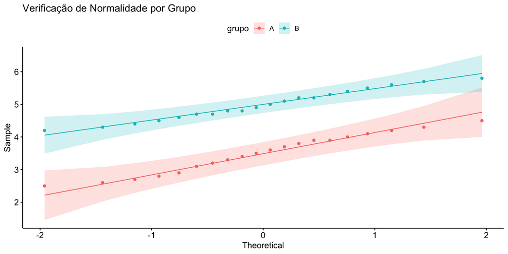

```r
# cria dois vetores para os tempos de permanência
versao_a <- c(3.2, 4.1, 2.8, 3.9, 3.5, 4.3, 2.9, 3.7, 4.0, 3.3,
              2.6, 3.8, 4.2, 3.1, 3.6, 2.7, 4.5, 3.4, 2.5, 3.9)

versao_b <- c(4.8, 5.2, 4.3, 5.6, 4.7, 5.1, 4.9, 5.4, 4.5, 5.0,
              4.6, 5.3, 4.4, 5.7, 4.8, 5.5, 4.2, 5.8, 4.7, 5.2)

# cria uma df para armazenar os dados
dados_ab <- data.frame(
  tempo = c(versao_a, versao_b),
  grupo = c(rep("A", 20), rep("B", 20))
)

# gráfico quantil-quantil (QQ) para verificar normalidade
ggqqplot(dados_ab, x = "tempo", color = "grupo") +
  labs(title = "Verificação de Normalidade por Grupo")
```

0 gráfico quantil-quantil (QQ) mostra que ambos os grupos estão razoavelmente próximos de uma distribuição normal.

```r
# estimativa por ic para diferença das médias
resultado_ab <- t.test(versao_b, versao_a, conf.level = 0.95)
resultado_ab$conf.int
```

```
[1] 1.1393 1.8307
attr(,"conf.level")
[1] 0.95
```

**Resultado**: IC 95% para (B - A) = [1.14, 1.83] minutos, como a estimativa por intervalo de confiança para a diferença entre as médias **não contém** zero, podemos concluir que a nova versão (B) é significativamente melhor que a versão atual (A) em termos de tempo médio de permanência.

**Conclusão**: Com 95% de confiança, a nova versão aumenta o tempo médio de permanência entre **1.14 e 1.83 minutos**.

**Decisão**: Implementar Versão B em produção.

## Verificação de Normalidade com Gráfico QQ

**Como Interpretar um Gráfico Quantil-Quantil**

**Objetivo**: Verificar se os dados seguem distribuição aproximadamente normal.

**Como criar**:

```r
library(ggpubr)
ggqqplot(dados, x = "variavel")
```

**Como interpretar**:

- **Linha diagonal**: distribuição normal teórica
- **Pontos**: quantis observados dos dados
- **Banda cinza**: região de referência baseada em quantis simulados de uma normal — serve como referência visual, **não** como intervalo de confiança formal

**Sinais de normalidade adequada**:

- Pontos próximos à linha diagonal
- Maioria dentro da banda cinza
- Padrão aproximadamente linear

**Problemas comuns**:

- Curvaturas (assimetria)
- Padrão em S (caudas pesadas ou leves)
- Muitos pontos fora da região de referência

**Regra prática**: Para $n \geq 30$, o Teorema Central do Limite garante que pequenas violações da normalidade são aceitáveis.

## Aplicação 3

**Estimação de Intervalo de Confiança para uma Média**

Você está conduzindo um estudo em para avaliar o impacto de um programa de educação financeira na quantidade média de poupança mensal dos participantes. O objetivo é determinar se o programa de educação financeira está ajudando os participantes a poupar dinheiro a cada mês.

Para isso, você coletou uma amostra aleatória de 30 participantes que completaram o programa e registrou a quantidade que cada um deles conseguiu poupar em um mês (em reais). Com esses dados, você deseja calcular o intervalo de confiança de 95% para a média da poupança mensal dos participantes, o que fornecerá uma estimativa da média de poupança que pode ser esperada na população geral de participantes do programa.

Os dados produzidos no estudo foram:

| participante | poupanca_mensal_reais |
| --- | --- |
| 1 | 150 |
| 2 | 200 |
| 3 | 180 |
| 4 | 220 |
| 5 | 190 |
| 6 | 170 |
| 7 | 210 |
| 8 | 230 |
| 9 | 160 |
| 10 | 200 |
| 11 | 180 |
| 12 | 175 |
| 13 | 190 |
| 14 | 210 |
| 15 | 185 |
| 16 | 165 |
| 17 | 220 |
| 18 | 195 |
| 19 | 205 |
| 20 | 215 |
| 21 | 190 |
| 22 | 200 |
| 23 | 185 |
| 24 | 180 |
| 25 | 210 |
| 26 | 195 |
| 27 | 175 |
| 28 | 170 |
| 29 | 200 |
| 30 | 190 |

- Armazenando os dados em uma data frame:

```r
# Carregar os dados simulados
dados_programa <- data.frame(
  participante = 1:30,
  poupanca = c(150, 200, 180, 220, 190, 170, 210, 230, 160, 200,
               180, 175, 190, 210, 185, 165, 220, 195, 205, 215,
               190, 200, 185, 180, 210, 195, 175, 170, 200, 190)
)

dados_programa
```

```
   participante poupanca
1             1      150
2             2      200
3             3      180
4             4      220
5             5      190
6             6      170
7             7      210
8             8      230
9             9      160
10           10      200
11           11      180
12           12      175
13           13      190
14           14      210
```

[output cut: 16 more lines]

- A primeira etapa é verificar se os dados seguem uma distribuicão aproximadamente normal. Vamos verificar esta hipótese usando um gráfico quantil-quantil, especificamente, podemos usar a função ggqqplot do pacote ggpubr para produzir o gráfico.

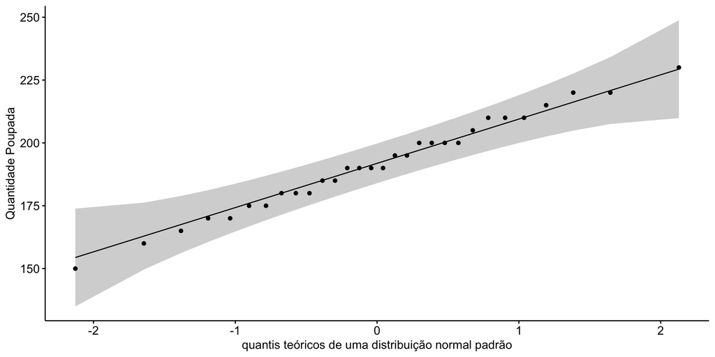

```r
# pacote utilizado
library(ggpubr)

# Gráfico quantil-quantil dos dados
ggqqplot(dados_programa, x = "poupanca") +
  xlab("quantis teóricos de uma distribuição normal padrão") +
  ylab("Quantidade Poupada")
```

O gráfico quantil-quantil mostre que é plausível considerar que os dados seguem uma distribuição aproximadamente normal.

Como as hipóteses necessárias para a validade de intervalos de confiança para uma média foram verificadas, passamos à estimação do intervalo de confiança:

```r
# estima o intervalo de confiança de 95% para a média das medições
resultado <- t.test(dados_programa$poupanca, conf.level = 0.95)
resultado
```

```
    One Sample t-test

data:  dados_programa$poupanca
t = 55, df = 29, p-value <0.0000000000000002
alternative hypothesis: true mean is not equal to 0
95 percent confidence interval:
 184.38 198.62
sample estimates:
mean of x
    191.5
```

```r
# exibe apenas a estimativa do IC
resultado <- resultado$conf.int
resultado
```

```
[1] 184.38 198.62
attr(,"conf.level")
[1] 0.95
```

#### Reportando o resultado

A quantidade média poupada pelos participantes do programa de educação financeira foi R$ 191,50 (IC 95% [184,38 198,62]).

Como a estimativa por intervalo de confiança para a média da poupança mensal não contém zero podemos concluir, com 95% de confiança, que os dados da pesquisa fornecem evidência de que a participação no programa de educação financeira tem um impacto positivo na quantidade poupada mensalmente, sendo que a quantidade média poupada pelos participantes varia entre R$ 184,38 e R$ 198,62 por mês.

## Aplicação 4

**Estimação de Intervalo de Confiança para Comparar Duas Médias**

Você está conduzindo um experimento em Economia Comportamental para avaliar o impacto de dois diferentes tipos de incentivo (monetário vs. não monetário) na produtividade dos funcionários medida como unidades produzidas por semana.

Você coletou uma amostra aleatória de funcionários e os dividiu em dois grupos:

- Grupo A (Incentivo Monetário)
- Grupo B (Incentivo Não Monetário)

Você mediu a produtividade dos funcionários (em unidades de produção por semana) após a implementação dos incentivos. Os dados produzidos pelo experimento foram:

| grupo | produtividade |
| --- | --- |
| A | 50 |
| A | 55 |
| A | 53 |
| A | 58 |
| A | 52 |
| A | 56 |
| A | 54 |
| A | 57 |
| A | 51 |
| A | 55 |
| A | 59 |
| A | 52 |
| A | 53 |
| A | 56 |
| A | 57 |
| A | 54 |
| A | 52 |
| A | 50 |
| A | 53 |
| A | 56 |
| B | 48 |
| B | 45 |
| B | 47 |
| B | 49 |
| B | 46 |
| B | 44 |
| B | 48 |
| B | 47 |
| B | 45 |
| B | 46 |
| B | 49 |
| B | 44 |
| B | 45 |
| B | 48 |
| B | 47 |
| B | 46 |
| B | 44 |
| B | 45 |
| B | 46 |
| B | 47 |

- Qual tipo de incentivo apresentou o maior impacto na produtividade dos funcionários?
- Armazenando os dados em uma data frame:

```r
# cria data frame para armazenar os dados
dados_incentivos <- data.frame(
  grupo = c(rep("A", 20), rep("B", 20)),
  produtividade = c(50, 55, 53, 58, 52, 56, 54, 57, 51, 55,
                    59, 52, 53, 56, 57, 54, 52, 50, 53, 56,
                    48, 45, 47, 49, 46, 44, 48, 47, 45, 46,
                    49, 44, 45, 48, 47, 46, 44, 45, 46, 47)
)
```

- Novamente, vamos verificar se os dados, referentes aos dois grupos do estudo, seguem uma distribuição aproximadamente normal utilizando gráficos quantil-quantil:

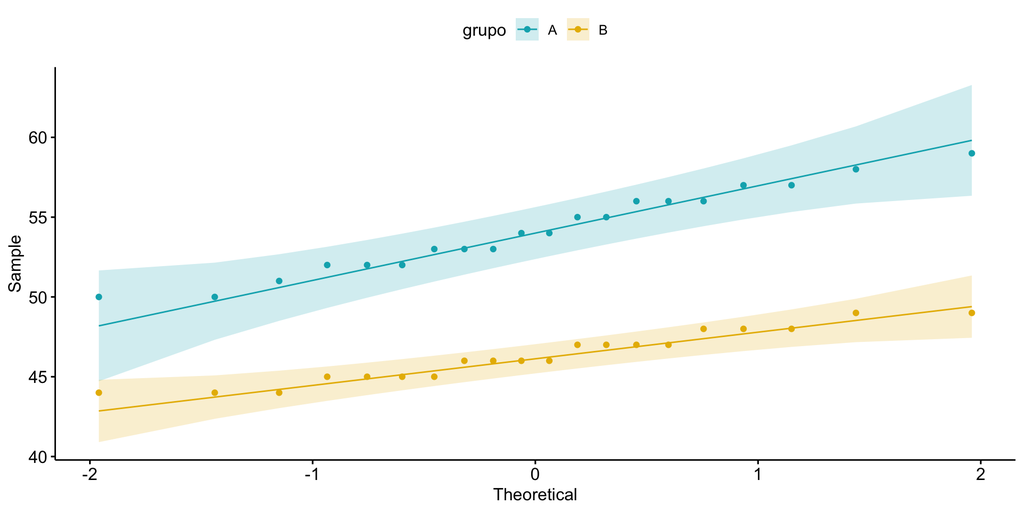

```r
# pacote utilizado
library(ggpubr)

# Gráfico quantil-quantil dos dados
ggqqplot(dados_incentivos, x = "produtividade",
         color = "grupo",
         palette = c("#00AFBB", "#E7B800"))
```

Vê-se que os dados de ambos os grupos estão dentro do intervalo de confiança, assim, é plausível considerar que os dados de ambos os grupos seguem uma distribuição aproximadamente normal.

A estimação de um intervalo de confiança para a diferença entre as médias dos dois grupos é obtida com:

```r
# Realizar o teste t para calcular o intervalo de confiança
resultado <- t.test(produtividade ~ grupo,
                    data = dados_incentivos,
                    conf.level = 0.95,
                    var.equal = FALSE)
resultado
```

```
    Welch Two Sample t-test

data:  produtividade by grupo
t = 11.5, df = 31.5, p-value = 0.00000000000081
alternative hypothesis: true difference in means between group A and group B is not equal to 0
95 percent confidence interval:
 6.4599 9.2401
sample estimates:
mean in group A mean in group B
          54.15           46.30
```

```r
# exibe apenas a estimativa do IC
resultado$conf.int
```

```
[1] 6.4599 9.2401
attr(,"conf.level")
[1] 0.95
```

#### Reportando o Resultado

A estimativa do intervalo com 95% de confiança, com correção de Welch, para a diferença entre as produtividades médias do grupo que recebeu incentivo monetário (M = 54,15 unidades produzidas) e o grupo qque recebeu incentivo não monetário (M = 46,30 unidades produzidas), sugere que a diferença é positiva e estatisticamente significativa (diferença = 7,85, IC 95% [6,46, 9,24], t(31,49) = 11,51).

## Tipos de Erro em Pesquisas

**Erros Relacionados à Amostragem**

**Erro de Amostragem** (coberto pela margem de erro):

- Variação natural dos resultados ao se usar uma amostra ao invés de um censo. Esse erro é controlável por métodos estatísticos, sendo o **único** refletido na margem de erro.

**Erro de Cobertura**:

- Ocorre quando parte da população-alvo tem **probabilidade nula ou desigual de seleção**, comprometendo a representatividade da amostra. *Exemplo*: exclusão de pessoas sem celular em pesquisas por telefone.

**Erro de Não-Resposta**:

- Quando há **diferenças sistemáticas entre quem responde e quem não responde**, introduzindo viés nos resultados.

**Implicação**: Mesmo com amostragem aleatória, esses erros podem comprometer a validade da inferência. Devem ser documentados e comunicados sempre que presentes.

## Tipos de Erro em Pesquisas

**Erros na Medição e Análise**

**Erro de Medição**:

- *Instrumento*: Perguntas ambíguas, enviesadas ou mal formuladas, ou ainda influência do entrevistador.
- *Declaração*: Respostas falsas, por pressão social ou desejo de agradar.

**Erro Temporal**:

- Mudanças reais na opinião pública entre a coleta dos dados e o evento de interesse (ex: eleição, lançamento de produto).

**Erro de Processamento**:

- Erros cometidos na entrada, codificação ou análise dos dados.

**Implicação**:

- Esses erros **não são refletidos na margem de erro estatística**, mas podem introduzir vieses significativos.
- A comunicação responsável deve explicitar que a margem de erro cobre **apenas a variabilidade amostral aleatória**.

## Referências

AMARI, S. Natural Gradient Works Efficiently in Learning. **Neural Computation**, v. 10, n. 2, p. 251–276, 1998.

BENSON, H. *et al.* [Study of the Therapeutic Effects of Intercessory Prayer (STEP) in cardiac bypass patients: A multicenter randomized trial of uncertainty and certainty of receiving intercessory prayer](https://doi.org/10.1016/j.ahj.2005.05.028). **American Heart Journal**, v. 151, n. 4, p. 934–942, 2006.

CARRILLO, H.; REID, I.; CASTELLANOS, J. A. On the Comparison of Uncertainty Criteria for Active SLAM. **IEEE Transactions on Robotics**, v. 29, n. 4, p. 980–985, 2012.

MARTENS, J. New Insights and Perspectives on the Natural Gradient Method. **Journal of Machine Learning Research**, v. 21, p. 1–76, 2020.

## Atualizando os Repositórios

**Instruções**

1. No terminal do RStudio, verifique quais arquivos/pastas foram modificados ou criados com:

```bash
git status
```

2. Você pode adicionar todos os arquivos de uma vez com:

```bash
git add .
```

3. Execute git status novamente para confirmar que todos os arquivos foram adicionados (aparecerão em verde sob “*Changes to be committed*”):

```bash
git status
```

4. Se tudo estiver em verde, faça um commit com uma mensagem descritiva:

```bash
git commit -m "atualizacoes aula 13"
```

5. Se algum arquivo ou pasta ainda aparecer em vermelho após o segundo git status, adicione as pastas/arquivos um por um:

```bash
git add relatorios/09-relatorio/10-relatorio.qmd
```

6. Execute git status novamente e faça o commit quando todos os arquivos estiverem em verde:

```bash
git commit -m "atualizacoes aula 13"
```

7. Envie o repositório local atualizado para o GitHub:

```bash
git push origin main
```